# Flashiness

# Discussion:

The first thing we have to do is look at the summary output. the summary shows the effect each variable has and also the fit of the model.

```r
summary(river_mlr_int)
```

```
##
## Call:
## lm(formula = flashiness ~ ln_flow * perm, data = river_ln)
##
## Residuals:
##      Min       1Q   Median       3Q      Max
## -0.06958 -0.03437 -0.01057  0.04145  0.10777
##
## Coefficients:
##                Estimate Std. Error t value Pr(>|t|)
## (Intercept)   0.1688015  0.0753305   2.241   0.0447 *
## ln_flow      -0.0111317  0.0117007  -0.951   0.3602
## perm          0.0065547  0.0024630   2.661   0.0207 *
## ln_flow:perm -0.0005693  0.0007328  -0.777   0.4523
## ---
## Signif. codes:  0 '***' 0.001 '**' 0.01 '*' 0.05 '.' 0.1 ' ' 1
##
## Residual standard error: 0.0578 on 12 degrees of freedom
## Multiple R-squared:  0.7636, Adjusted R-squared:  0.7045
## F-statistic: 12.92 on 3 and 12 DF,  p-value: 0.0004571
```

We can see that the R squared is 0.7.

##### Visualize

The best way to get an overveiw of what a model is doing is by visulaizing it.

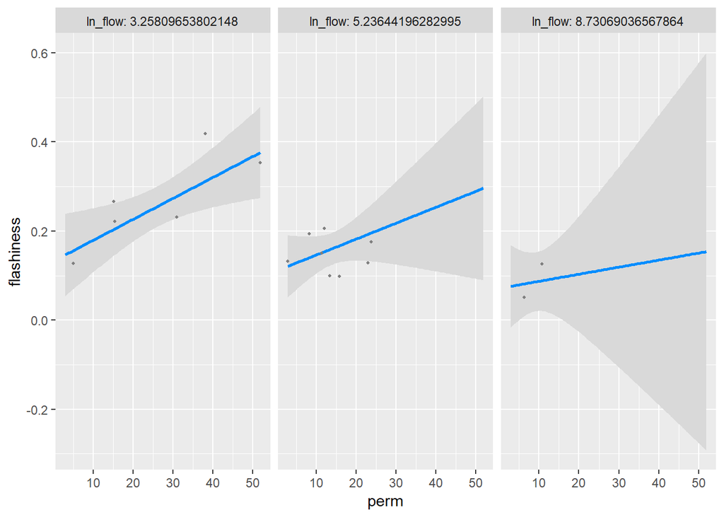

```r
visreg(river_mlr_int, "perm", "ln_flow", gg= TRUE)
```

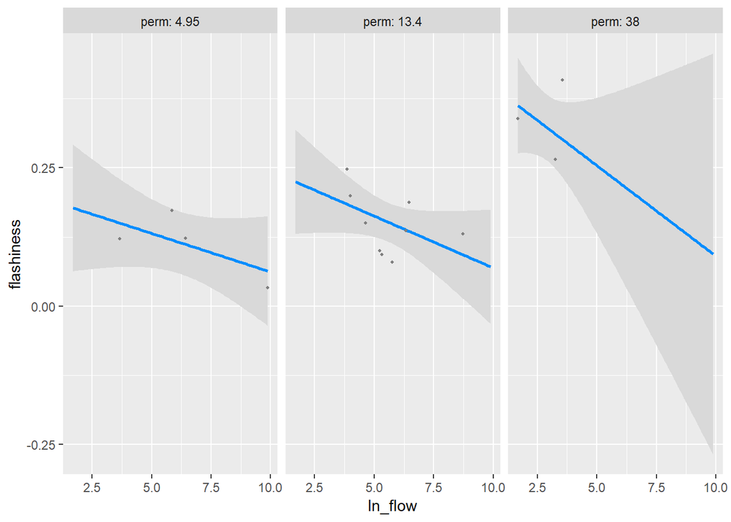

```r
visreg(river_mlr_int, "ln_flow", "perm", gg= TRUE)
```

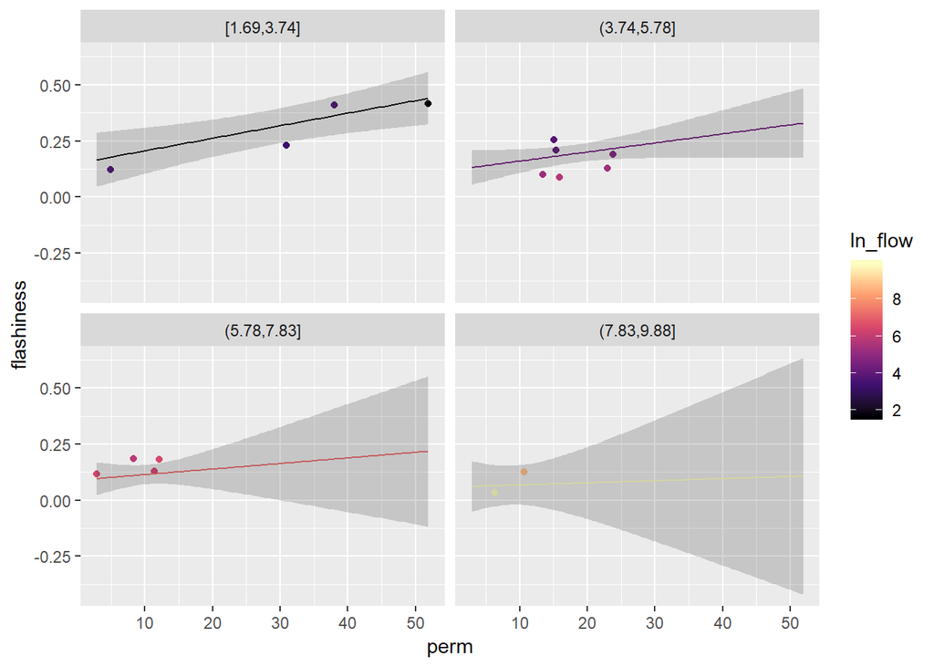

```r
river_int_explore <- data_grid(river_ln,
                               perm = seq_range(perm, 100),
                               ln_flow = seq_range(ln_flow, 4))%>%
  cbind(predict(river_mlr_int, newdata = ., interval = "confidence"))%>%
  rename(flashiness = fit)

ggplot(river_ln,
       aes(x = perm, y = flashiness, color = ln_flow)) +
  geom_point() +
  geom_line(data = river_int_explore, aes(group = ln_flow)) +
  geom_ribbon(data = river_int_explore, aes(ymin = lwr, ymax = upr), alpha = 0.2, color = NA) +
  facet_wrap(~cut_interval(ln_flow,4)) +
  scale_color_viridis_c(option = "A")
```

This graph shows how the model behaves under different conditions. This graph shows something very similar to the previous, with more bins. We can see from this that the varibility increases drastically with higher flow.

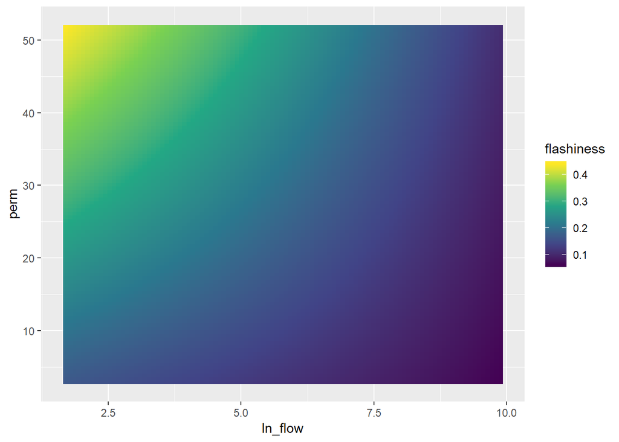

```r
river_surface <- data_grid(river_ln,
                            ln_flow = seq_range(ln_flow, 100),
                            perm = seq_range(perm, 100)) %>%
  add_predictions(river_mlr_int, var = "flashiness")

ggplot(river_surface,
       aes(x = ln_flow, y = perm, fill = flashiness)) +
  geom_raster() +
  scale_fill_viridis_c(option = "D")
```

This graph is a 2D representation of how the varibales are interacting. We can see that as flow decreases and permability incerases flashiness reaches a maximum.

# Conclusion(1)

From the above model we can say that permiabilty is highly corrilated to flashiness. In the future I can use this model to predicit which ungaged rivers will be flashy and be able to better pick study sites.

# Methods(2)

##### Data Cleaning

The data that was taken from an in situ flourometer in Town Brook in Quincy, MA does not report as claen data. There are three errors that can occur. First there can be rows with missing data.

```r
FDOM <- read_csv("../../data/FDOM181212.csv")
FDOM[51701,c(1:5)]
```

```
## # A tibble: 1 x 5
##   Date      Time   `N/U` Count     y
##   <chr>     <time> <int> <int> <int>
## 1 7/30/2018 04:28    460    NA   460
```

The second problem is that there can be additional columns of data that cause the entire row to be false data.

```r
FDOM[51902,]
```

```
## # A tibble: 1 x 9
##   Date      Time   `N/U` Count     y bad1  bad2  bad3  bad4
##   <chr>     <time> <int> <int> <int> <chr> <chr> <chr> <chr>
## 1 7/30/2018 06:50    460    NA   460 88    541   <NA>  <NA>
```

The third problem is a result of the sensor being physically moved by debris causing it to read zero or close to zero. This can be seen when the count is less than ~ 100.

```r
FDOM[51888:51800,c(1:6)]
```

```
## # A tibble: 89 x 6
##    Date      Time   `N/U` Count     y bad1
##    <chr>     <time> <int> <int> <int> <chr>
##  1 7/30/2018 06:40    460    70   541 <NA>
##  2 7/30/2018 06:40    460    77   542 <NA>
##  3 7/30/2018    NA     NA   460    77 542
##  4 7/30/2018 06:40    460    86   542 <NA>
##  5 7/30/2018 06:40    460    74   542 <NA>
##  6 7/30/2018 06:40    460    71   542 <NA>
##  7 7/30/2018 06:40    460    77   542 <NA>
##  8 7/30/2018 06:40    460    85   542 <NA>
##  9 7/30/2018 06:40    460    74   542 <NA>
## 10 7/30/2018 06:40    460    72   543 <NA>
## # ... with 79 more rows
```

I created a way to clean this data using dplyr.

```r
FDOM_clean <- FDOM %>%
  drop_na(Date, Time,'N/U', Count, y) %>%#drops rows with missing values
  filter(is.na(bad1), is.na(bad2), is.na(bad3), is.na(bad4)) %>%#drops rows with extra values
  select(Date, Time, Count) %>% # only uses date and count
 filter(Count > 100) %>% #get rid of low numbers
  filter(Count < 3000) #get rid of high numbers

head(FDOM_clean)
```

```
## # A tibble: 6 x 3
##   Date      Time   Count
##   <chr>     <time> <int>
## 1 7/20/2018 15:35    603
## 2 7/20/2018 15:35    601
## 3 7/20/2018 15:35    614
## 4 7/20/2018 15:35    603
## 5 7/20/2018 15:35    598
## 6 7/20/2018 15:35    609
```

```r
FDOM_clean_lag <-FDOM_clean %>%
  mutate(DateTime = parse_date_time(paste(Date, Time, sep = " "), order="mdyHMS")) %>%# get date time in proper variable type
 as_tbl_time(FDOM181118_clean, index = DateTime) %>%
  mutate(time_since_last = (Time - lag(Time)))%>%
  select(DateTime, Count, time_since_last) %>%
  as.data.frame() #getting lag time
#filter(is.na(time_since_last)) #see if an NA's only one at the start

 FDOM_clean_lag[1,3] = "600" #fix first time bucket

head(FDOM_clean_lag)
```

```
##              DateTime Count time_since_last
## 1 2018-07-20 15:35:54   603        600 secs
## 2 2018-07-20 15:35:55   601          1 secs
## 3 2018-07-20 15:35:55   614          0 secs
## 4 2018-07-20 15:35:56   603          1 secs
## 5 2018-07-20 15:35:56   598          0 secs
## 6 2018-07-20 15:35:57   609          1 secs
```

```r
length(FDOM_clean_lag)
```

```
## [1] 3
```

```r
FDOM_15 <- FDOM_clean_lag %>%
  group_by(by15 = cut(DateTime, "15 min")) %>%
  select(by15, Count) %>%
  summarise(Count = mean(Count)) %>%
  mutate(by15 = as_datetime(by15)) %>%
  mutate(by15 = by15 + minutes(3)) %>%
  filter(by15 >= "2018-07-01") %>%
  filter(by15 <= "2018-12-12") %>%
  drop_na()

head(FDOM_15)
```

```
## # A tibble: 6 x 2
##   by15                Count
##   <dttm>              <dbl>
## 1 2018-07-20 15:30:00  606.
## 2 2018-07-20 15:45:00  618.
## 3 2018-07-20 16:00:00  659.
## 4 2018-07-20 16:15:00  627.
## 5 2018-07-20 16:30:00  638.
## 6 2018-07-20 16:45:00  635.
```

```r
length(FDOM_15)
```

```
## [1] 2
```

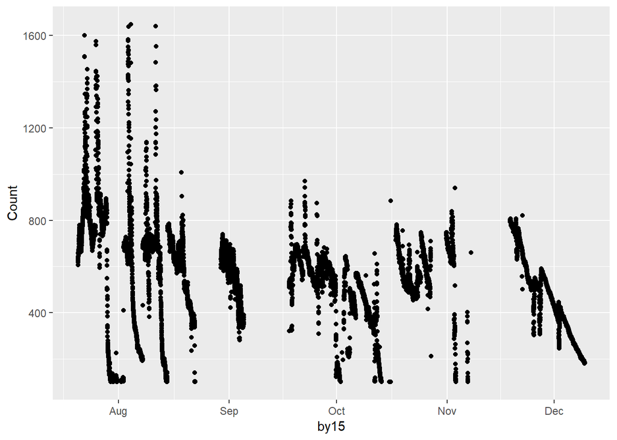

```r
ggplot(FDOM_15,
       aes(x = by15, y = Count))+
  geom_point()
```

The above graph show all the data from July through Decemebr 2018 that I collected.

The next thing I have to do is use my discrete sampes to determine concentration of CDOM. The big assumption is that biofowling occurs linearly.

```r
Sample <- read_csv("../../Data/Sample.csv")
Sample
```

```
## # A tibble: 2 x 7
##   Date             `[CDOM]` count cells  delta delta_cell   start
##   <chr>               <dbl> <dbl> <int>  <dbl>      <dbl>   <dbl>
## 1 10/31/2018 17:15     51.4  731.   272 0.0704    0.00159  0.0704
## 2 11/6/2018 20:45      51.4  102     NA 0.504    NA       NA
```

```r
Delta_Cell <- Sample[1,6] %>%
  as.numeric()

Delta_Cell
```

```
## [1] 0.001593675
```

```r
start <- Sample[1,7]%>%
  as.numeric()

start
```

```
## [1] 0.07037978
```

```r
FDOM_15_Conc <- FDOM_15 %>%
  mutate(corrected = start)%>%
  mutate(conc = corrected*Count) %>%
  select(by15, conc)

FDOM_15_Conc
```

```
## # A tibble: 9,098 x 2
##    by15                 conc
##    <dttm>              <dbl>
##  1 2018-07-20 15:30:00  42.7
##  2 2018-07-20 15:45:00  43.5
##  3 2018-07-20 16:00:00  46.4
##  4 2018-07-20 16:15:00  44.2
##  5 2018-07-20 16:30:00  44.9
##  6 2018-07-20 16:45:00  44.7
##  7 2018-07-20 17:00:00  45.2
##  8 2018-07-20 17:15:00  45.1
##  9 2018-07-20 17:30:00  45.1
## 10 2018-07-20 17:45:00  45.3
## # ... with 9,088 more rows
```

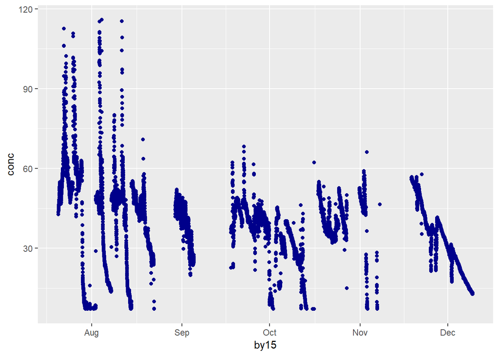

```r
ggplot(data = FDOM_15_Conc,
       aes(x = by15, y = conc))+
  geom_point(color = "darkblue")+
  theme_grey()
```

This changed the count into concentraion which is a unit we can deal with.

The next thing we have to do is to pull data from USGS.

```r
Discharge <- read_csv("../../data/181212_gage1.csv") %>%
  as.data.frame()
```

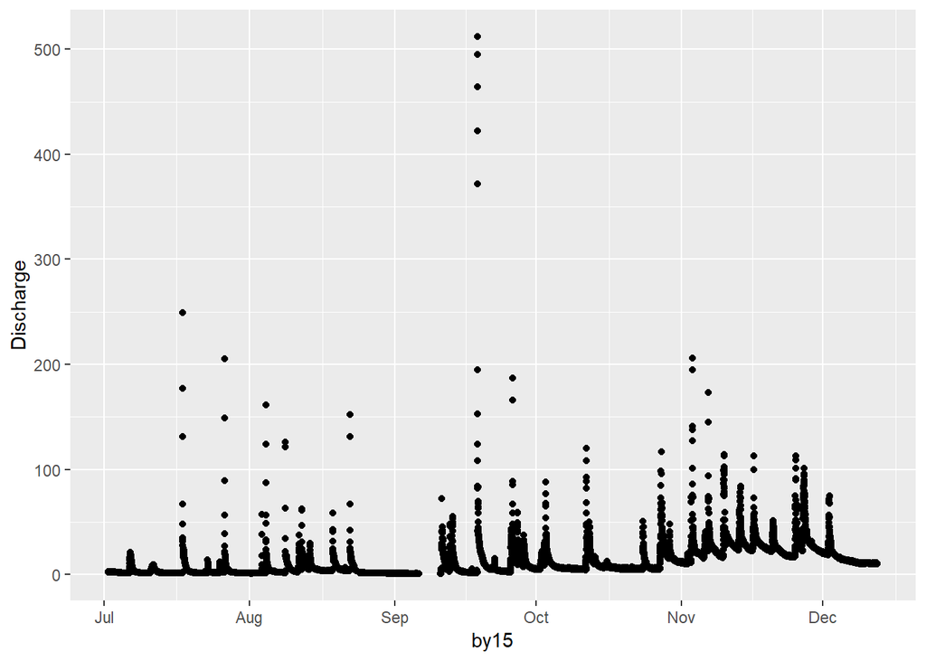

```r
Discharge_15 <- Discharge %>%
  mutate(by15 = parse_date_time(paste(Date_time, sep = " "), order="mdyHM")) %>%# get date time in proper variable type
  select(by15, Discharge)


ggplot(Discharge_15,
       aes(x = by15, y = Discharge)) +
  geom_point()
```

Next we need to pull data from Boston water and sewer

```r
Rain <- read_csv("../../data/181212_rain.csv")
Rain_clean <- Rain %>%
  mutate(DateTime = parse_date_time(paste(Datetime, sep = " "), order="mdyHM")) %>%# get date time in proper variable type
  select(DateTime, Rain)
```

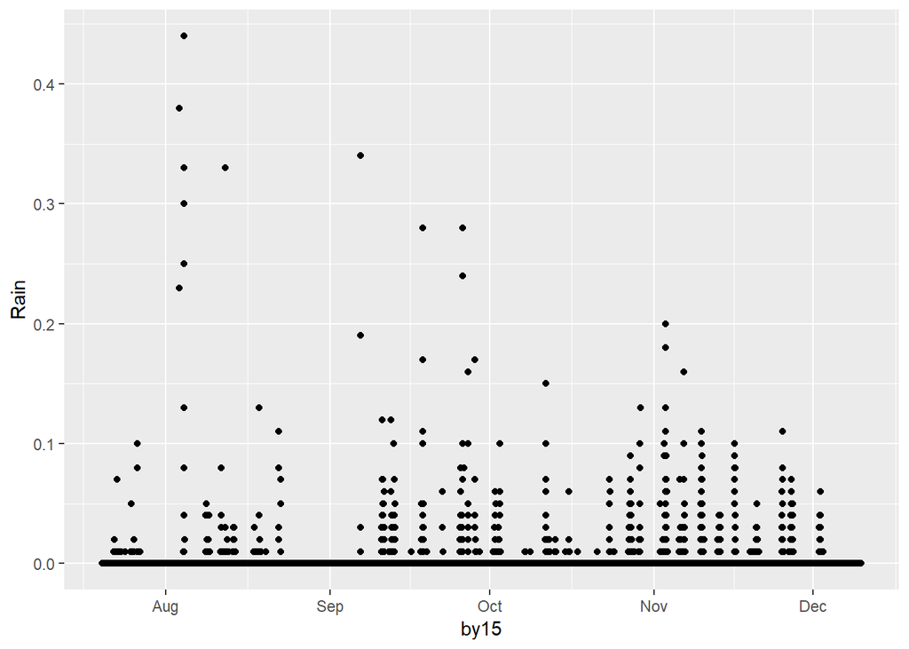

```r
Rain_15 <- Rain_clean %>%
  group_by(by15 = cut(DateTime, "15 min")) %>%
  select(by15, Rain) %>%
  summarise(Rain = sum(Rain)) %>%
  mutate(by15= as_datetime(by15))

ggplot(Rain_15,
       aes(x = by15, y = Rain))+
  geom_point()
```

Now we need to join all the data together and since they all have a by15 column this is very straigt forward. I chose to do an inner join to avoid any incomplete data. I did an outer join as well and they both have the same length.

```r
library(caTools)
FDOM_Discharge <- inner_join(FDOM_15_Conc, Discharge_15, by = "by15")


FDOM_Discharge_Rain <- inner_join(FDOM_Discharge, Rain_15, by = "by15")

FDOM_Discharge_Rain
```

```
## # A tibble: 9,090 x 4
##    by15                 conc Discharge  Rain
##    <dttm>              <dbl>     <dbl> <dbl>
##  1 2018-07-20 15:30:00  42.7      1.54     0
##  2 2018-07-20 15:45:00  43.5      1.52     0
##  3 2018-07-20 16:00:00  46.4      1.63     0
##  4 2018-07-20 16:15:00  44.2      1.59     0
##  5 2018-07-20 16:30:00  44.9      1.56     0
##  6 2018-07-20 16:45:00  44.7      1.52     0
##  7 2018-07-20 17:00:00  45.2      1.47     0
##  8 2018-07-20 17:15:00  45.1      1.51     0
##  9 2018-07-20 17:30:00  45.1      1.58     0
## 10 2018-07-20 17:45:00  45.3      1.53     0
## # ... with 9,080 more rows
```

The next thing we need to do is pull out individual storms. I did this visually (In the future we will use a better method to find storms). The length of a storm was counted when the discharge returend to baseline flow. For each storm intensity, rain total and total carbon discahred was calculated.

```r
#add some rain parameters
storm1 <- FDOM_Discharge_Rain %>%
  filter(by15 >= "2018-07-21 23:30:00")%>%
  filter(by15 <= "2018-07-23 07:00")%>%
  mutate(intensity = max(Rain)) %>%
  mutate(rain_tot = (cumsum(Rain)))%>%
  mutate(carbon = conc*28.3168*Discharge)%>%
  mutate(sumcarb = cumsum(carbon))%>%
  mutate(storm_num = 1)%>%
  mutate(time = (length(Rain)*15)-15)


storm2 <- FDOM_Discharge_Rain %>%
  filter(by15 >= "2018-07-23 07:00")%>%
  filter(by15 <= "2018-07-23 19:30")%>%
  mutate(intensity = max(Rain)) %>%
  mutate(rain_tot = (cumsum(Rain)))%>%
  mutate(carbon = conc*28.3168*Discharge)%>%
  mutate(sumcarb = cumsum(carbon)) %>%
  mutate(storm_num = 2)%>%
  mutate(time = (length(Rain)*15)-15)



storm3 <- FDOM_Discharge_Rain %>%
  filter(by15 >= "2018-07-25 6:00")%>%
  filter(by15 <= "2018-07-26 10:30")%>%
  mutate(intensity = max(Rain)) %>%
  mutate(rain_tot = cumsum(Rain))%>%
  mutate(carbon = conc*28.3168*Discharge)%>%
  mutate(sumcarb = cumsum(carbon)) %>%
  mutate(storm_num = 3)%>%
  mutate(time = (length(Rain)*15)-15)



storm4 <- FDOM_Discharge_Rain %>%
  filter(by15 >= "2018-07-26 10:30:00")%>%
  filter(by15 <= "2018-07-27 15:30")%>%
  mutate(intensity = max(Rain)) %>%
  mutate(rain_tot = (cumsum(Rain)))%>%
  mutate(carbon = conc*28.3168*Discharge)%>%
  mutate(sumcarb = cumsum(carbon))%>%
  mutate(storm_num = 4)%>%
  mutate(time = (length(Rain)*15)-15)


storm5 <- FDOM_Discharge_Rain %>%
  filter(by15 >= "2018-08-08 09:15")%>%
  filter(by15 <= "2018-08-10 09:00")%>%
  mutate(intensity = max(Rain)) %>%
  mutate(rain_tot = (cumsum(Rain)))%>%
  mutate(carbon = conc*28.3168*Discharge)%>%
  mutate(sumcarb = cumsum(carbon))%>%
  mutate(storm_num = 5)%>%
  mutate(time = (length(Rain)*15)-15)


storm6 <- FDOM_Discharge_Rain %>%
  filter(by15 >= "2018-08-11 03:30")%>%
  filter(by15 <= "2018-08-11 22:30")%>%
  mutate(intensity = max(Rain)) %>%
  mutate(rain_tot = (cumsum(Rain)))%>%
  mutate(carbon = conc*28.3168*Discharge)%>%
  mutate(sumcarb = cumsum(carbon))%>%
  mutate(storm_num = 6)%>%
  mutate(time = (length(Rain)*15)-15)

storm7 <- FDOM_Discharge_Rain %>%
  filter(by15 >= "2018-08-11 22:30")%>%
  filter(by15 <= "2018-08-13 12:15")%>%
  mutate(intensity = max(Rain)) %>%
  mutate(rain_tot = (cumsum(Rain)))%>%
  mutate(carbon = conc*28.3168*Discharge)%>%
  mutate(sumcarb = cumsum(carbon))%>%
  mutate(storm_num = 7)%>%
  mutate(time = (length(Rain)*15)-15)



storm8 <- FDOM_Discharge_Rain %>%
  filter(by15 >= "2018-08-13 12:15")%>%
  filter(by15 <= "2018-08-15 17:45")%>%
  mutate(intensity = max(Rain)) %>%
  mutate(rain_tot = (cumsum(Rain)))%>%
  mutate(carbon = conc*28.3168*Discharge)%>%
  mutate(sumcarb = cumsum(carbon))%>%
  mutate(storm_num = 8)%>%
  mutate(time = (length(Rain)*15)-15)



storm9 <- FDOM_Discharge_Rain %>%
  filter(by15 >= "2018-08-17 11:15")%>%
  filter(by15 <= "2018-08-18 08:45")%>%
  mutate(intensity = max(Rain)) %>%
  mutate(rain_tot = (cumsum(Rain)))%>%
  mutate(carbon = conc*28.3168*Discharge)%>%
  mutate(sumcarb = cumsum(carbon))%>%
  mutate(storm_num = 9)%>%
  mutate(time = (length(Rain)*15)-15)

storm10 <- FDOM_Discharge_Rain %>%
  filter(by15 >= "2018-08-18 10:00")%>%
  filter(by15 <= "2018-08-20 18:15")%>%
  mutate(intensity = max(Rain)) %>%
  mutate(rain_tot = (cumsum(Rain)))%>%
  mutate(carbon = conc*28.3168*Discharge)%>%
  mutate(sumcarb = cumsum(carbon))%>%
  mutate(storm_num = 10)%>%
  mutate(time = (length(Rain)*15)-15)
```

##### Next we are going to look at a few of these storms over time and see how rain affects them.

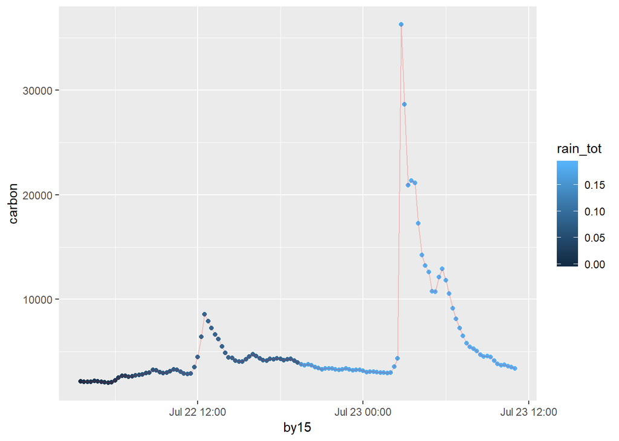

```r
ggplot(storm1,
       aes(x = by15, y = carbon, color = rain_tot)) +
  geom_point()+
  geom_line(color = "red", alpha = 0.2)
```

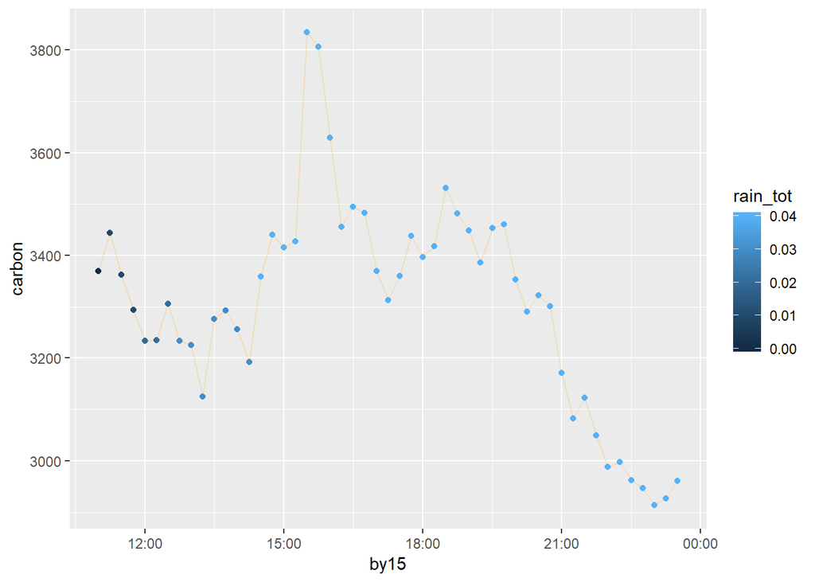

```r
ggplot(storm2,
       aes(x = by15, y = carbon, color = rain_tot)) +
  geom_line(color = "orange", alpha = 0.2)+
  geom_point()
```

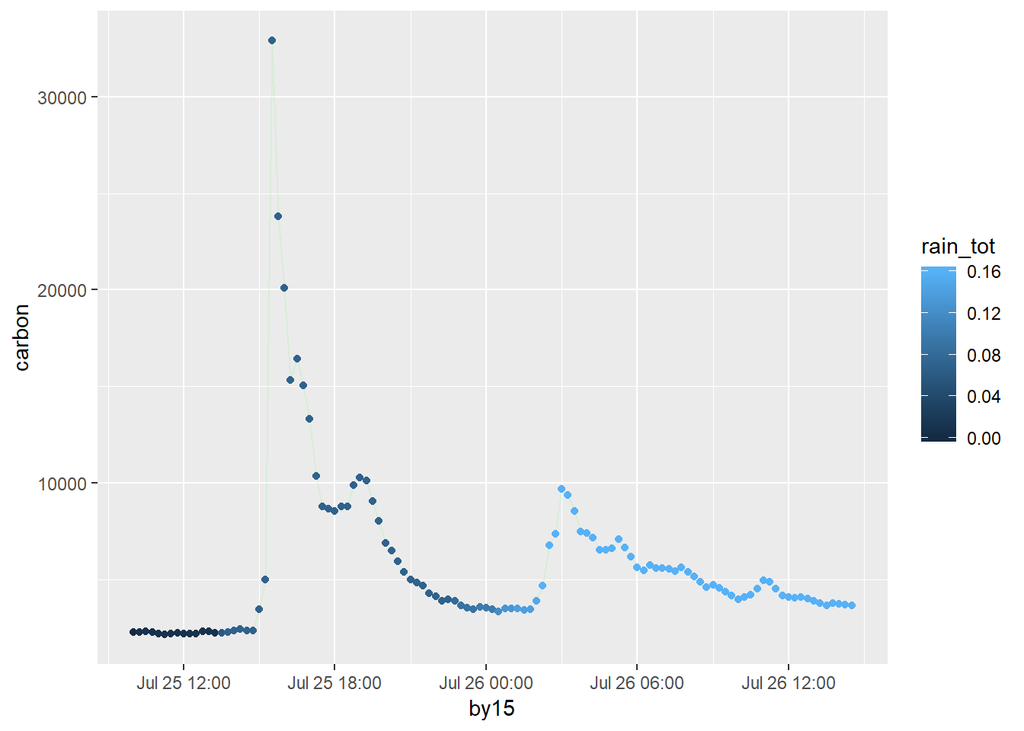

```r
ggplot(storm3,
       aes(x = by15, y = carbon, color = rain_tot)) +
  geom_line(color = "lightgreen", alpha = 0.2)+
  geom_point()
```

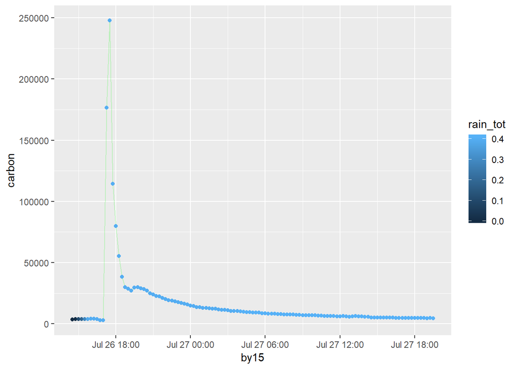

```r
ggplot(storm4,
       aes(x = by15, y = carbon, color = rain_tot)) +
  geom_line(color = "green", alpha = 0.2)+
  geom_point()
```

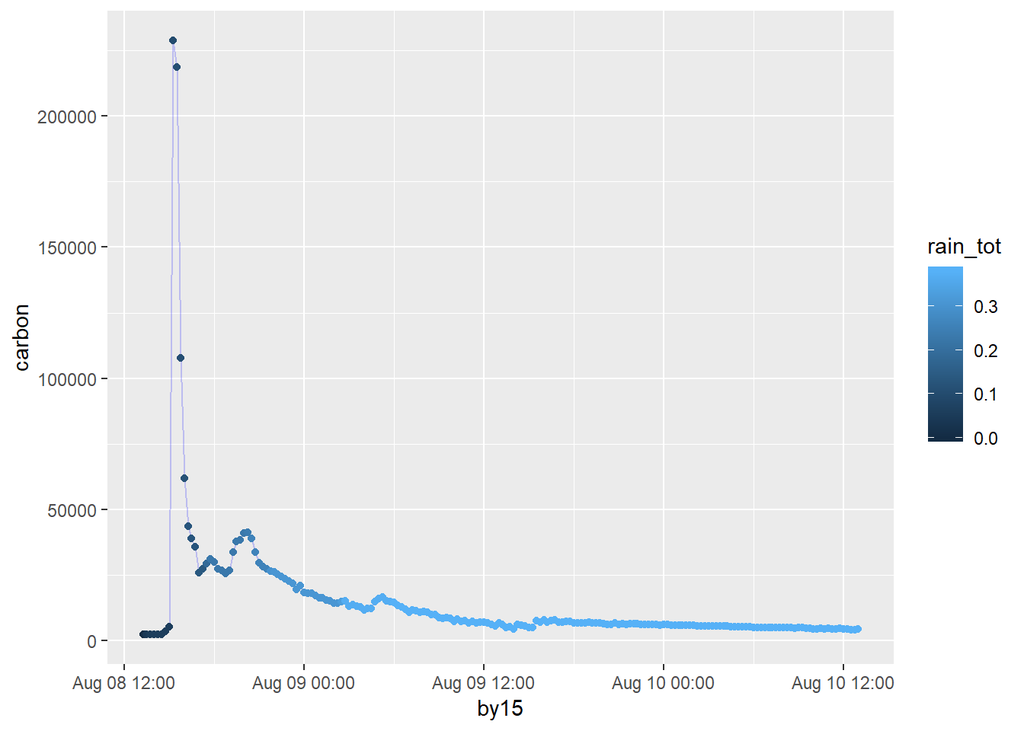

```r
ggplot(storm5,
       aes(x = by15, y = carbon, color = rain_tot)) +
  geom_line(color = "blue", alpha = 0.2)+
  geom_point()
```

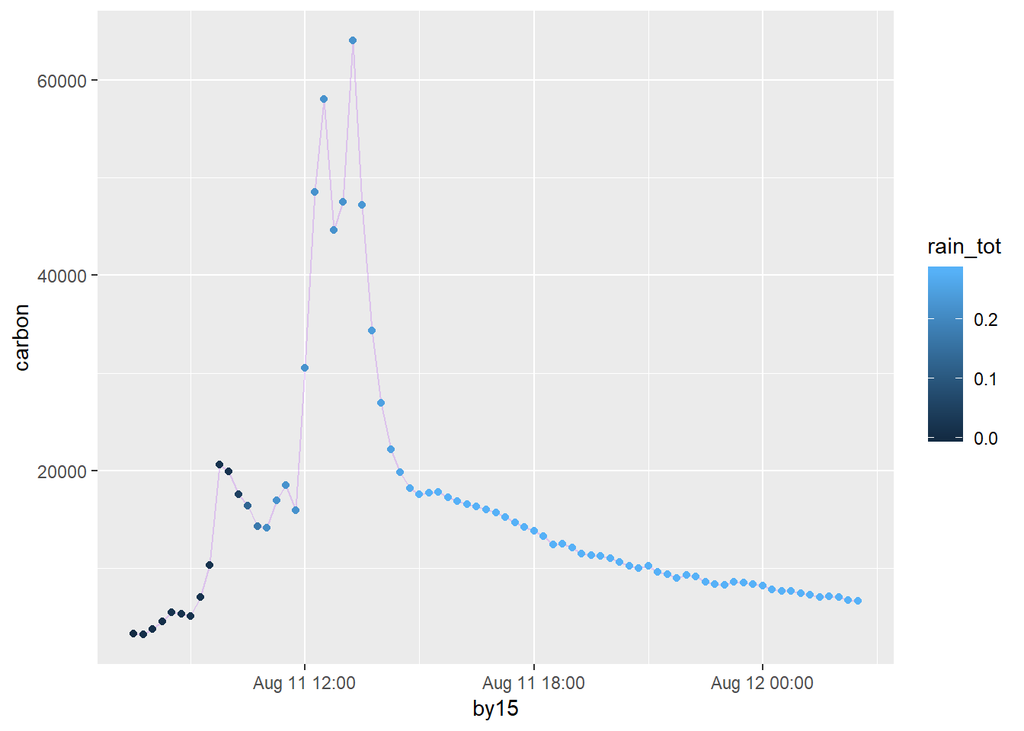

```r
ggplot(storm6,
       aes(x = by15, y = carbon, color = rain_tot)) +
  geom_line(color = "purple", alpha = 0.2)+
  geom_point()
```

As can be seen in the above graphs some storms see a peak in carbon discharge during peak rainfall and some see it after. Some storms have multiple peaks and others only have one. The goal of this model is to find out what parameters affect total carbon regardless of timing during the storm.

Below is the code to put together a dataframe with all 10 storms.

```r
storm <- rbind(last(storm1), last(storm2), last(storm3), last(storm4), last(storm5), last(storm6), last(storm7), last(storm8), last(storm9), last(storm10)) %>%
  select(storm_num, sumcarb, rain_tot, time, intensity)

storm
```

```
## # A tibble: 10 x 5
##    storm_num  sumcarb rain_tot  time intensity
##        <dbl>    <dbl>    <dbl> <dbl>     <dbl>
##  1         1  686639.     0.19  1890    0.0700
##  2         2  168626.     0.04   750    0.01
##  3         3  664042.     0.16  1710    0.05
##  4         4 1849108.     0.41  1740    0.1
##  5         5 2729318.     0.38  2865    0.05
##  6         6 1189099.     0.28  1140    0.08
##  7         7 1401107.     0.48  2250    0.33
##  8         8 1097642.     0.17  3180    0.03
##  9         9  389200.     0.05  1290    0.03
## 10        10 2374742.     0.31  3375    0.13
```

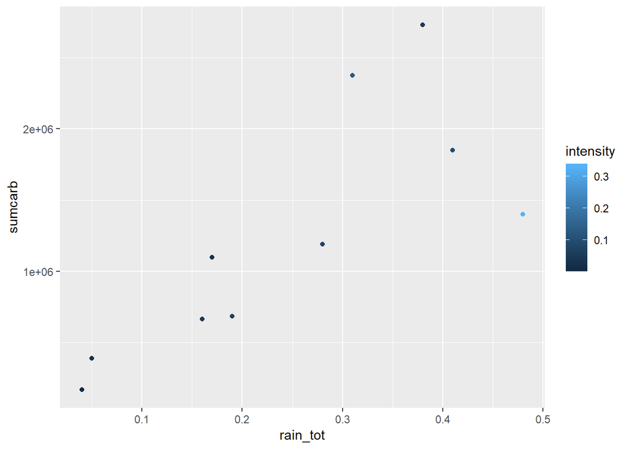

```r
ggplot(storm,
       aes(x= rain_tot, y = sumcarb, color = intensity))+
  geom_point()
```

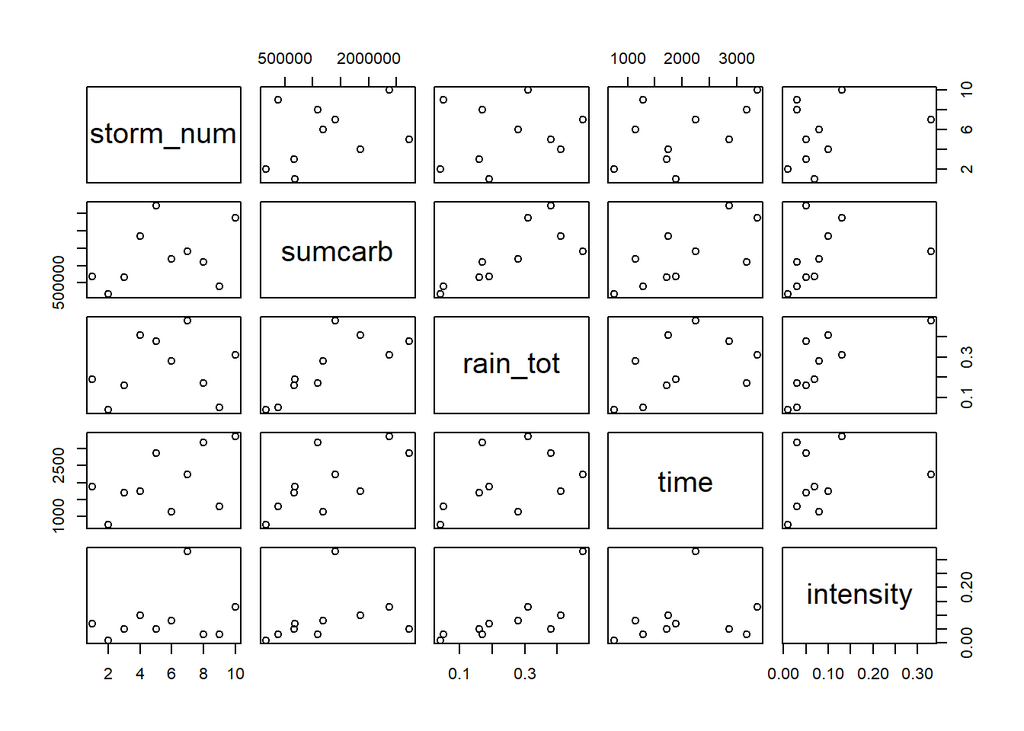

```r
pairs(storm)
```

Above are two visuals showing the relationship between different paramters.

The next step is to make a linear model

```r
storm_mlr <- lm(sumcarb ~ intensity + rain_tot + time, data = storm)
```

# Results(2)

We need to test our assumptions of Linearity, Normality & homoscedasticity of residuals and Minimal collinearity.

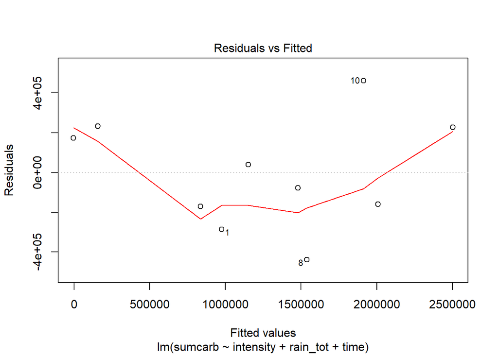

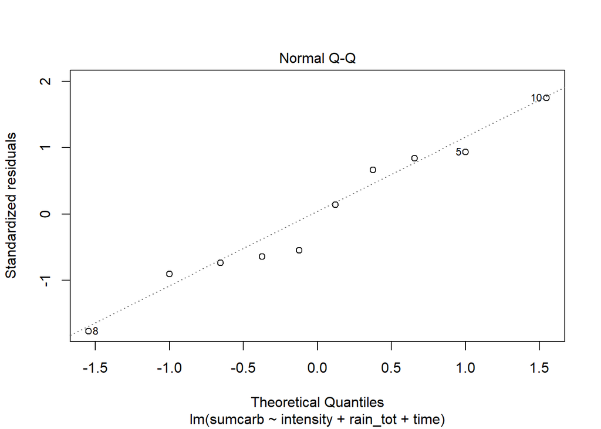

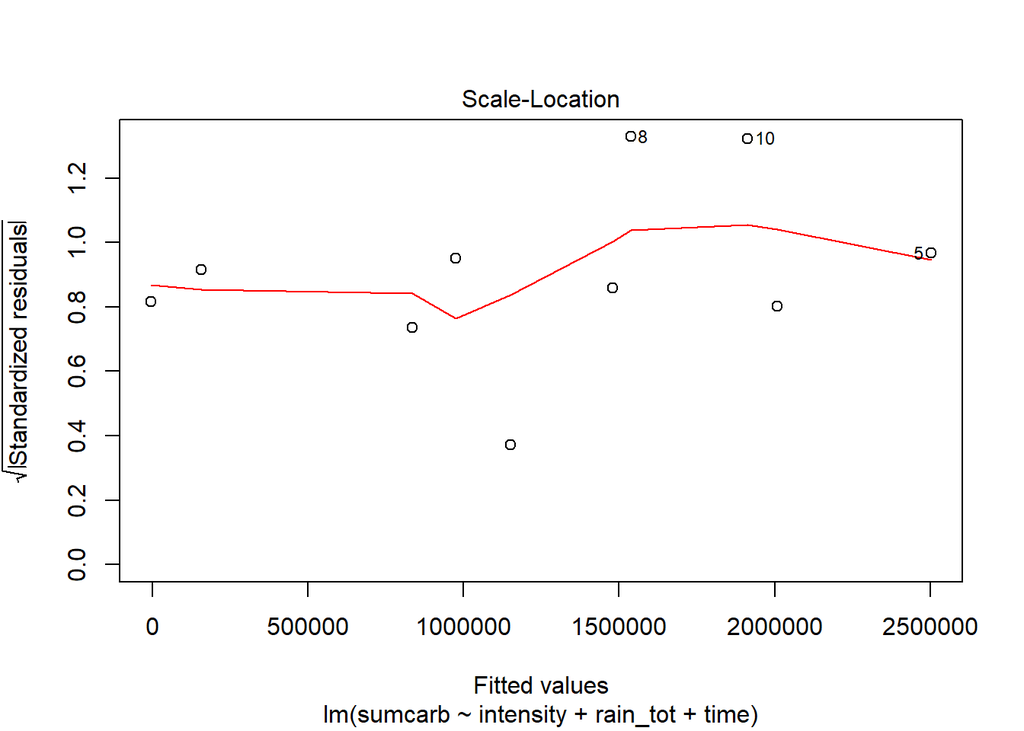

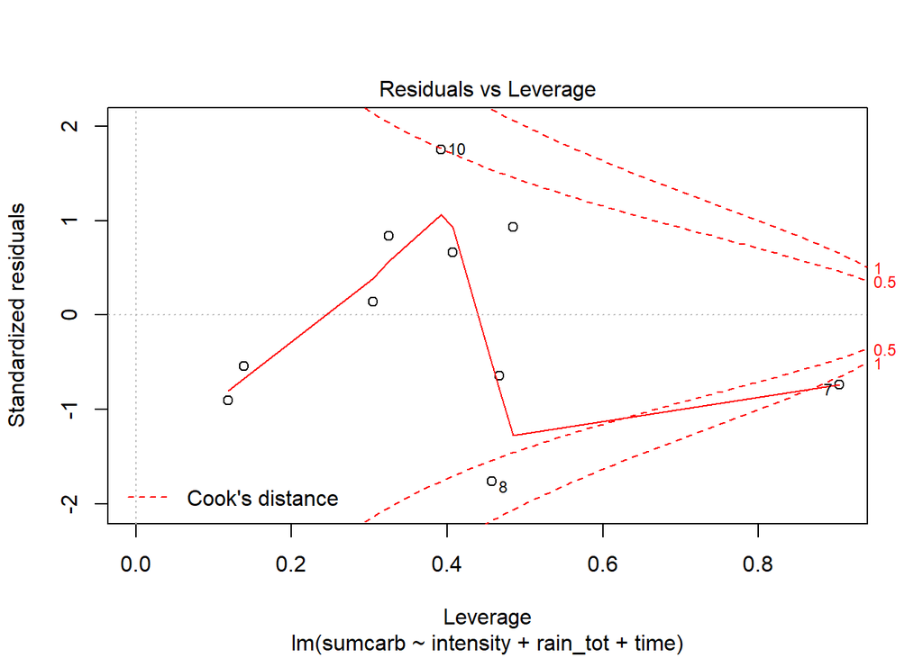

```r
plot(storm_mlr)
```

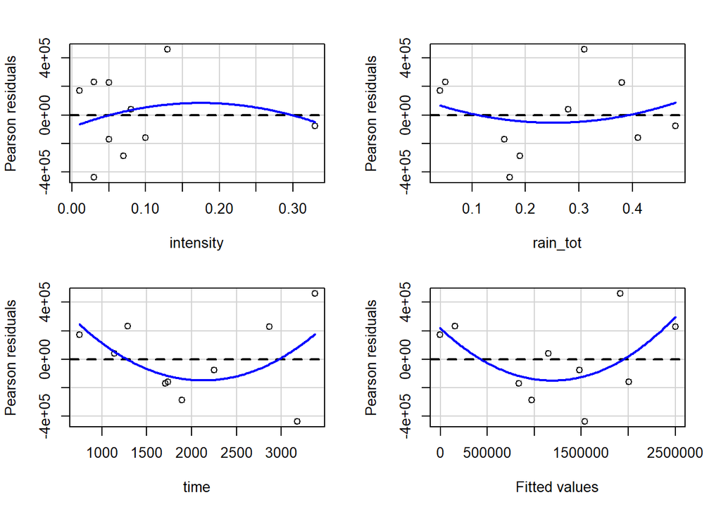

```r
residualPlots(storm_mlr, test = FALSE)
```

```r
#multicollinearity
vif(storm_mlr)
```

```
## intensity  rain_tot      time
##  2.265012  2.661585  1.273738
```

```r
#correlation matrix
storm %>%
  select(intensity, rain_tot, time)%>%
  cor()
```

```
##           intensity  rain_tot      time
## intensity 1.0000000 0.7400980 0.2344657
## rain_tot  0.7400980 1.0000000 0.4424724
## time      0.2344657 0.4424724 1.0000000
```

```r
#high because when high intensity usulay high total
```

We can see from the above that our residuals are not perfect, probably due to the small sample size.

```r
Anova(storm_mlr)
```

```
## Anova Table (Type II tests)
##
## Response: sumcarb
##               Sum Sq Df F value   Pr(>F)
## intensity 7.9229e+11  1  6.9202 0.039027 *
## rain_tot  2.3944e+12  1 20.9137 0.003798 **
## time      7.7570e+11  1  6.7753 0.040502 *
## Residuals 6.8694e+11  6
## ---
## Signif. codes:  0 '***' 0.001 '**' 0.01 '*' 0.05 '.' 0.1 ' ' 1
```

```r
summary(storm_mlr)
```

```
##
## Call:
## lm(formula = sumcarb ~ intensity + rain_tot + time, data = storm)
##
## Residuals:
##     Min      1Q  Median      3Q     Max
## -439951 -167702  -19215  213518  462006
##
## Coefficients:
##               Estimate Std. Error t value Pr(>|t|)
## (Intercept)  -461625.6   290257.3  -1.590   0.1628
## intensity   -4841469.4  1840424.3  -2.631   0.0390 *
## rain_tot     5616724.3  1228195.2   4.573   0.0038 **
## time             374.1      143.7   2.603   0.0405 *
## ---
## Signif. codes:  0 '***' 0.001 '**' 0.01 '*' 0.05 '.' 0.1 ' ' 1
##
## Residual standard error: 338400 on 6 degrees of freedom
## Multiple R-squared:  0.8932, Adjusted R-squared:  0.8398
## F-statistic: 16.73 on 3 and 6 DF,  p-value: 0.002555
```

From the anova and the summary we can see how well our model fits. All of the inculded parameters are signifigant (p < 0.05).